# Repoducible Research Week 2 Assignment

The data for this assignnment was forked and cloned from the [RepData_PeerAssesment1 Repo](https://github.com/rdpeng/RepData_PeerAssessment1)

Loaded and preprocessed the data as well as looked at a summary of it.

```r
data <- read.csv("/home/ruixin/RepData_PeerAssessment1/activity.csv")
summary(data)
```

```
##      steps                date          interval
##  Min.   :  0.00   2012-10-01:  288   Min.   :   0.0
##  1st Qu.:  0.00   2012-10-02:  288   1st Qu.: 588.8
##  Median :  0.00   2012-10-03:  288   Median :1177.5
##  Mean   : 37.38   2012-10-04:  288   Mean   :1177.5
##  3rd Qu.: 12.00   2012-10-05:  288   3rd Qu.:1766.2
##  Max.   :806.00   2012-10-06:  288   Max.   :2355.0
##  NA's   :2304     (Other)   :15840
```

### What is the mean total number of steps taken per day?

**Calculate the total number of steps taken per day**

```r
library(dplyr)
dataNoNA <- data[complete.cases(data),]
dataNoNAsum <- aggregate(. ~ date, dataNoNA, sum)
```

**Make a histogram of the total number of steps taken each day**

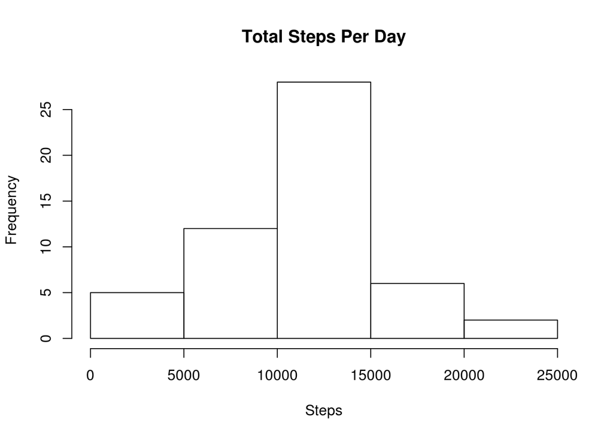

```r
hist(dataNoNAsum$steps, main = "Total Steps Per Day", xlab = "Steps")
```

**Calculate and report the mean and median of the total number of steps taken per day**

```r
summary(dataNoNAsum)
```

```
##          date        steps          interval
##  2012-10-02: 1   Min.   :   41   Min.   :339120
##  2012-10-03: 1   1st Qu.: 8841   1st Qu.:339120
##  2012-10-04: 1   Median :10765   Median :339120
##  2012-10-05: 1   Mean   :10766   Mean   :339120
##  2012-10-06: 1   3rd Qu.:13294   3rd Qu.:339120
##  2012-10-07: 1   Max.   :21194   Max.   :339120
##  (Other)   :47
```

The mean of the total number of steps taken per day is 10766 and the median is 10765.

### What is the average daily activity pattern?

**Make a time series plot (i.e. type = “l”) of the 5-minute interval (x-axis) and the average number of steps taken, averaged across all days (y-axis)**

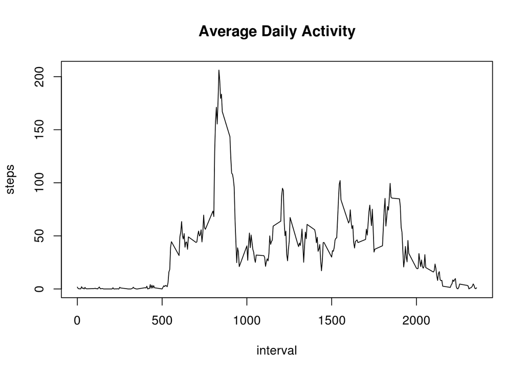

```r
dataNoNAmean <- aggregate(steps ~ interval, dataNoNA, mean)
plot(dataNoNAmean, type = "l", main = "Average Daily Activity")
```

```r
summary(dataNoNAmean)
```

```
##     interval          steps
##  Min.   :   0.0   Min.   :  0.000
##  1st Qu.: 588.8   1st Qu.:  2.486
##  Median :1177.5   Median : 34.113
##  Mean   :1177.5   Mean   : 37.383
##  3rd Qu.:1766.2   3rd Qu.: 52.835
##  Max.   :2355.0   Max.   :206.170
```

**Which 5-minute interval, on average across all the days in the dataset, contains the maximum number of steps?**

```r
dataNoNAmean$interval[which.max(dataNoNAmean$steps)]
```

```
## [1] 835
```

The interval with the highest number of steps is interval 835.

### Imputing missing values

**Calculate and report the total number of missing values in the dataset (i.e. the total number of rows with NAs)**

```r
dataincomplete <- data[!complete.cases(data),]
summary(dataincomplete)
```

```
##      steps              date        interval
##  Min.   : NA    2012-10-01:288   Min.   :   0.0
##  1st Qu.: NA    2012-10-08:288   1st Qu.: 588.8
##  Median : NA    2012-11-01:288   Median :1177.5
##  Mean   :NaN    2012-11-04:288   Mean   :1177.5
##  3rd Qu.: NA    2012-11-09:288   3rd Qu.:1766.2
##  Max.   : NA    2012-11-10:288   Max.   :2355.0
##  NA's   :2304   (Other)   :576
```

There are 2304 missing values.

**Devise a strategy for filling in all of the missing values in the dataset. The strategy does not need to be sophisticated.** I will fill in the NAs with the mean of intervals.

```r
compdata <- data
for (i in 1:nrow(compdata)) {
    if(is.na(compdata$steps[i])) {
        val <-dataNoNAmean$steps[which(dataNoNAmean$interval == compdata$interval[i])]
        compdata$steps[i] <- val
    }
}
```

**Make a histogram of the total number of steps taken each day**

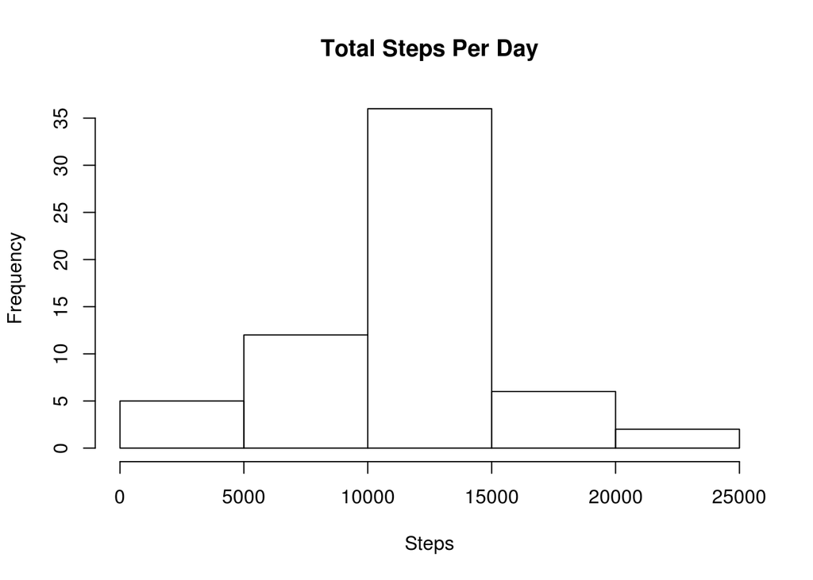

```r
compdatasum <- aggregate(.~ date, compdata, sum)
hist(compdatasum$steps, main = "Total Steps Per Day", xlab = "Steps")
```

```r
summary(compdata)
```

```
##      steps                date          interval
##  Min.   :  0.00   2012-10-01:  288   Min.   :   0.0
##  1st Qu.:  0.00   2012-10-02:  288   1st Qu.: 588.8
##  Median :  0.00   2012-10-03:  288   Median :1177.5
##  Mean   : 37.38   2012-10-04:  288   Mean   :1177.5
##  3rd Qu.: 27.00   2012-10-05:  288   3rd Qu.:1766.2
##  Max.   :806.00   2012-10-06:  288   Max.   :2355.0
##                   (Other)   :15840
```

### Are there differences in activity patterns between weekdays and weekends?

**Create a new factor variable in the dataset with two levels – “weekday” and “weekend” indicating whether a given date is a weekday or weekend day.**

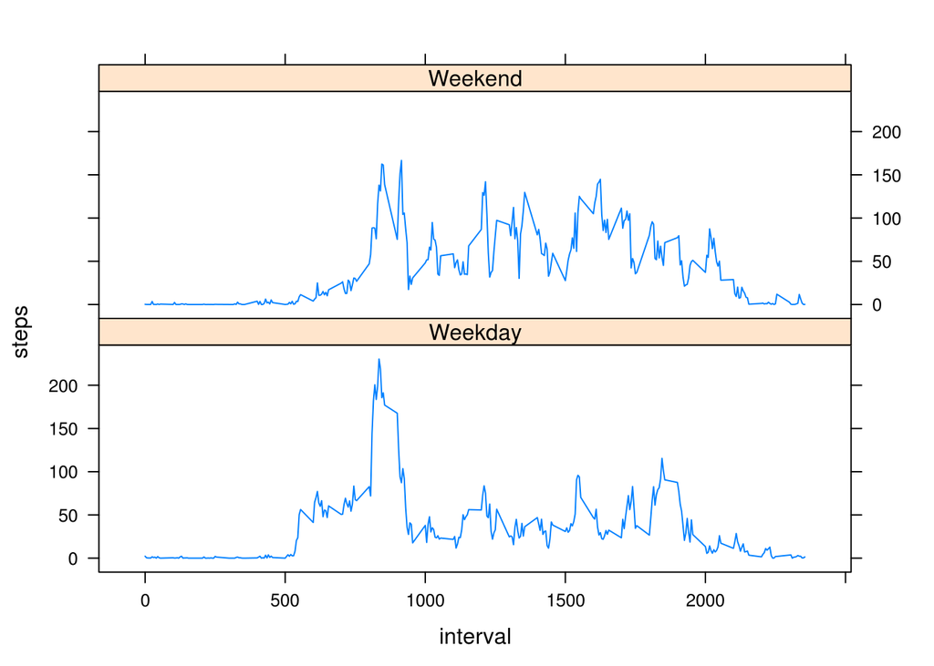

```r
compdata["weekday"] <-NA
compdata$weekday <-weekdays(as.Date(compdata$date))
compdata$weekday.type <- ifelse(compdata$weekday == "Saturday" | compdata$weekday == "Sunday", "Weekend", "Weekday")
finaldata <- select(compdata, weekday.type, steps, interval)
finaldatamean <- aggregate(steps ~ interval+weekday.type, finaldata, mean)
library(lattice)
xyplot(steps ~ interval | weekday.type, finaldatamean , type = "l", layout = c(1,2))
```

Looking out the two tables, it does show there are some similarities in the person’s activity between the Weekday and the Weekday. A similarity is they are most active in the morning then slow down around noon. A difference is they are more active in the Weekend compared to the Weekday.